# HW9

Shengyuan Wang

2023-04-11

I worked with Carissa and Wenxuan.

### Q1 The rectangular case for $A=QR$

In class we made code demos for the $A=QR$ factorization using either Givens rotations or Householder reflections. You can find the codes we wrote on our course spreadsheet.

To test your code, make a random $60\times15$ matrix, factor it, and then print out $\max(|A - QR|)$.

```r
# generate random matrix A with 60 rows and 15 columns
A <- matrix(runif(60*15), 60, 15)

# initialize Q and R
n <- nrow(A)
m <- ncol(A)
Q <- diag(n)
R <- A

# apply given rotations
for (j in 1:m) {
  for (i in n:(j+1)) {
    # apply given rotation to zero out R[i,j]
    x <- R[(i-1),j]
    y <- R[i,j]
    r <- sqrt(x^2 + y^2)
    c <- x/r
    s <- -y/r
    G <- diag(n)
    # Here instead of change (i, j), (i, j-1), (i-1, j), and (i-1, j-1), we make change on (i, i), (i-1, i), (i, i-1), (i-1, i-1)
    G[(i-1),(i-1)] <- c
    G[i,i] <- c
    G[i,(i-1)] <- s
    G[(i-1),i] <- -s
    R <- G %*% R
    Q <- Q %*% t(G)
  }
}

# check max error |A-QR|
print(max(abs(A - Q %*% R)))
```

```
## [1] 1.665335e-15
```

### Q2 The Fast Fourier transform

We already saw that the DCT converts function values on a Chebyshev grid into Chebyshev coefficients. Similarly, the fast Fourier transform converts function values at *evenly spaced points* into *trigonometric coefficients*. For example, let $f(x) = 12\cos(0x) + 16\sin(x) + 28\cos(x) + 2 \cos(2x) +18\sin(3x)$; the function values on a 9-point evenly spaced grid from $0$ to $2\pi$, but not including $2\pi$, are:

```r
x <- (0:8) * 2*pi / 9 # evenly spaced points
y <- 12 * cos(0*x) + 16*sin(x) + 28*cos(x) + 2*cos(2*x) + 18*sin(3*x)
y
```

```
## [1]  42.000000  59.669600  15.151231  10.856406   8.281475 -33.840084 -16.856406
## [8]  14.814297   7.923482
```

We’ll take the FFT and then lightly process the result. Do you see the coefficients that we used in the definition of $f$ appearing here?

```r
co <- fft(y)
co <- co / length(co) * 2
co[1] <- co[1]/2
co
```

```
## [1]  1.200000e+01+0.000000e+00i  2.800000e+01-1.600000e+01i
## [3]  2.000000e+00-0.000000e+00i  0.000000e+00-1.800000e+01i
## [5] -3.355341e-15-3.157968e-15i  0.000000e+00+1.578984e-15i
## [7]  0.000000e+00+1.800000e+01i  2.000000e+00-0.000000e+00i
## [9]  2.800000e+01+1.600000e+01i
```

The first entry of `co` contains the constant term (aka the one with $\cos(0x)$). Then the next three entries have information about the $\cos$ and $\sin$ coefficients: cosines in the real part, sines in the imaginary part (with a minus). The fifth entry is zero, meaning that there is no $\sin(4x)$ term and no $\cos(4x)$ term. With a grid of nine points, we can’t resolve anything higher than frequency 4, so we’re done there. The last entries in the vector don’t contain new information - they’re just repeats of what we saw before in reverse order and with the imaginary parts multiplied by $-1$. So really we could get all of the information out of `co[1:5]`.

Question: I started with a function
$$g(x)
= a_0 + b_1\sin(x) + a_1\cos(x) + b_2\sin(2x) + a_2\cos(2x) + \cdots +
b_{8}\sin(8x) + a_8\cos(8x).$$
Then I made a 17-point evenly spaced grid, found the function values, took the FFT, and post-processed the output just like above. I got this vector:

```r
co <- c(3,14+22i,8+8i,3-1i,-2-2i,0.4,0.2-0.1i,0,0.1i,-0.1i,0,0.2+0.1i,0.4,-2+2i,3+1i,8-8i,14-22i)
co
```

```
##  [1]  3.0+ 0.0i 14.0+22.0i  8.0+ 8.0i  3.0- 1.0i -2.0- 2.0i  0.4+ 0.0i
##  [7]  0.2- 0.1i  0.0+ 0.0i  0.0+ 0.1i  0.0- 0.1i  0.0+ 0.0i  0.2+ 0.1i
## [13]  0.4+ 0.0i -2.0+ 2.0i  3.0+ 1.0i  8.0- 8.0i 14.0-22.0i
```

Make a graph of the original function on the interval $[0,2\pi]$.

From the vector above, we can get the function
$$g(x) = 3\cos(0x)-22\sin(x) +
14\cos(x)-8\sin(2x)+8\cos(2x)+\sin(3x)+3\cos(3x)$$
$$+2\sin(4x)-2\cos(4x)+0.4\cos(5x)+0.1\sin(6x)+0.2\cos(6x)
-0.1\sin(8x)$$

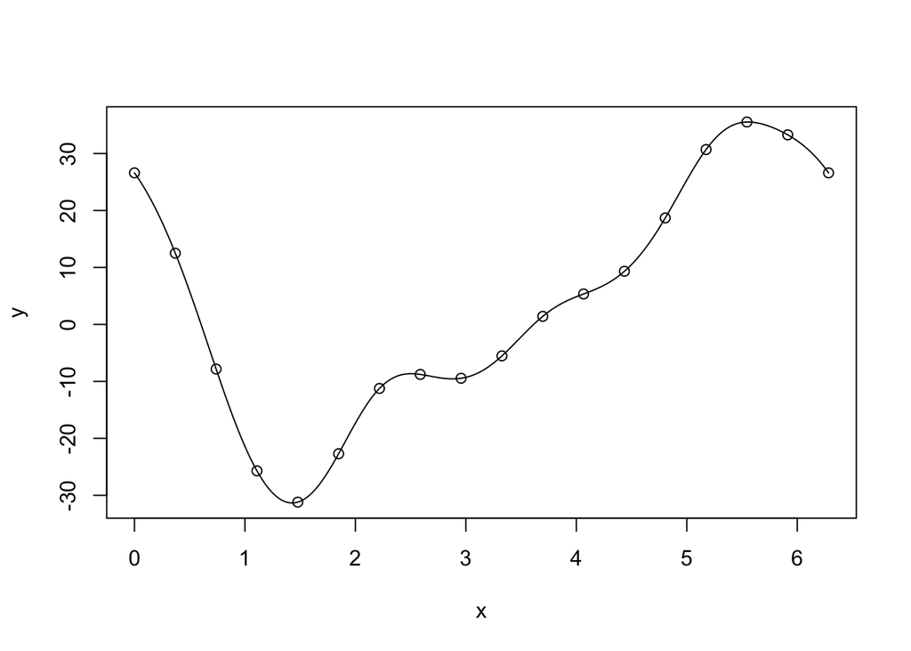

```r
f <- function(x){
  return(3*cos(0*x)-22*sin(x) + 14*cos(x)-8*sin(2*x)+8*cos(2*x)+sin(3*x)+3*cos(3*x)+2*sin(4*x)-2*cos(4*x)+0.4*cos(5*x)+0.1*sin(6*x)+0.2*cos(6*x) -0.1*sin(8*x))
}
xx <- (0:17) * 2*pi / 17
yy <- f(xx)
x <- seq(0,2*pi,length=800)
y <- f(x)
plot(x, y, 'l')
points(xx, yy)
```

### Q3 Least squares localization

A hiker is calling for help and we need to know where to send a rescue team! Here is a picture showing four cell towers (dots) and four circles, each indicating a distance from the tower where the hiker’s cellphone is estimated to lie.

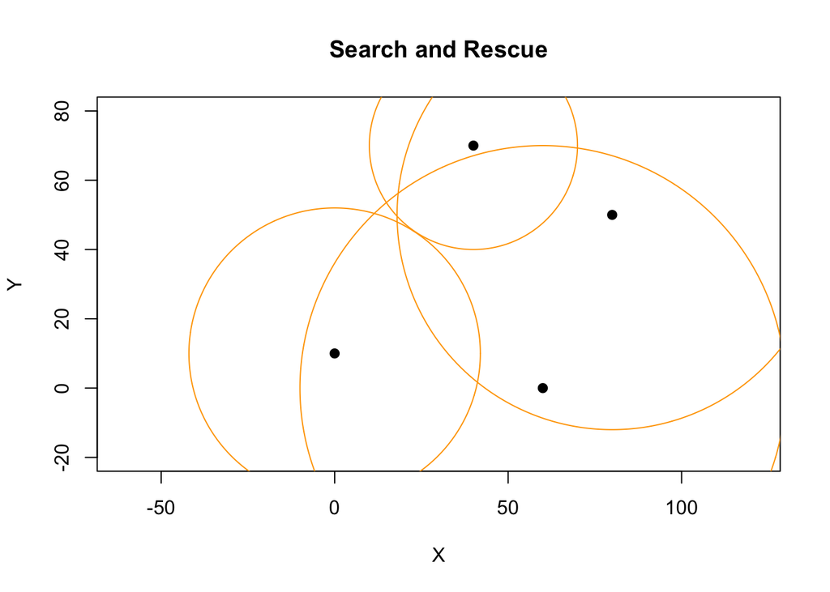

```r
tx <- c(0,60,80,40)
ty <- c(10,0,50,70)
d <- c(42,70,62,30)
tt <- seq(0,2*pi,length=800)
plot(tx,ty,'p',pch=19,asp=1,
     xlim=c(-20,80),ylim=c(-20,80),
     main="Search and Rescue",
     xlab="X",ylab="Y")
for (j in 1:4){
  lines(tx[j]+cos(tt)*d[j],ty[j]+sin(tt)*d[j],col="orange")
}
```

Unfortunately, the four circles do not all meet at a single point. That is, there is no location $(x,y)$ satisfying all of these equations:
$$\begin{align*}
(x-0)^2 + (y-10)^2 &= 42^2\\
(x-60)^2 + (y-0)^2 &= 70^2\\
(x-80)^2 + (y-50)^2 &= 62^2\\
(x-40)^2 + (y-70)^2 &= 30^2
\end{align*}$$
These equations are not linear in $x$ and $y$, so our existing theory doesn’t directly address this situation. One way to solve this problem is to minimize an error function like this:
$$E(x,y) = ((x-0)^2 + (y-10)^2 - 42^2)^2 + \cdots +
((x-40)^2 + (y-70)^2 - 30^2)^2,$$
possibly by using Newton’s method.

An alternative way to solve this problem is to make it into an ordinary least-squares problem. One method to do this is to pick two equations, say the $i$-th and the $j$-th, to get equations like
$$\begin{align*}
(x-X_i)^2 + (y-Y_i)^2 &= d_i^2\\
(x-X_j)^2 + (y-Y_j)^2 &= d_j^2\\
\end{align*}$$
On expanding and rearranging, we get
$$\begin{align*}
x^2+y^2 -2xX_i - 2yY_i &= d_i^2- X_i^2- Y_i^2\\
x^2+y^2 -2xX_j - 2yY_j &= d_j^2- X_j^2- Y_j^2\\
\end{align*}$$
Then we can subtract these equations to get a new equation that’s linear in $x$ and $y$. There were four equations originally, so there are six ways to choose a pair of them. Therefore we arrive at an $A\vec x=b$ where $A$ is $6\times 2$; the unknown vector $\vec x$ is really $\vec x = (x,y)$.

One way or another, figure out where the rescue team should go! Explain your work and add your suggested destination to the graph with the circles.

```r
f <- function(x,y){
  return((x^2 + (y-10)^2 -42^2)^2+((x-60)^2 + (y-0)^2 -70^2)^2+((x-80)^2 + (y-50)^2 -62^2)^2+((x-40)^2 + (y-70)^2 -30^2)^2)
} # this isn't actually needed!

Hf <- function(x,y){ # Hessian matrix of second derivatives
  fxx <- 16*(3*x^2-270*x+y^2-65*y+7723)
  fxy <- 16*(x*(2*y-65)-90*y+3400)
  fyy <- 16*(x^2-90*x+3*(y^2-65*y+1891))
  H <- cbind(c(fxx,fxy),c(fxy,fyy))
  return(H)
}

gradf <- function(x,y){ # gradient (vector of first derivatives)
  fx <- 16*(x^3-135*x^2+x*(y^2-65*y+7723)-5*(9*y^2-680*y+27524))
  fy <- 8*(x^2*(2*y-65)-20*x*(9*y-340)+2*y^3-195*y^2+11346*y-314080)
  return(c(fx,fy))
}

v <- c(0.0,0.0)

for (j in 1:10){
  print(v)
  x <- v[1]
  y <- v[2]
  dv <- qr.solve(Hf(x,y), -gradf(x,y)) # linear solve
  v <- v + dv # update
}
```

```
## [1] 0 0
## [1]  7.651551 23.096197
## [1]  9.540736 48.299233
## [1] 15.21288 51.94935
## [1] 16.09157 52.25445
## [1] 16.10948 52.25735
## [1] 16.10949 52.25735
## [1] 16.10949 52.25735
## [1] 16.10949 52.25735
## [1] 16.10949 52.25735
```

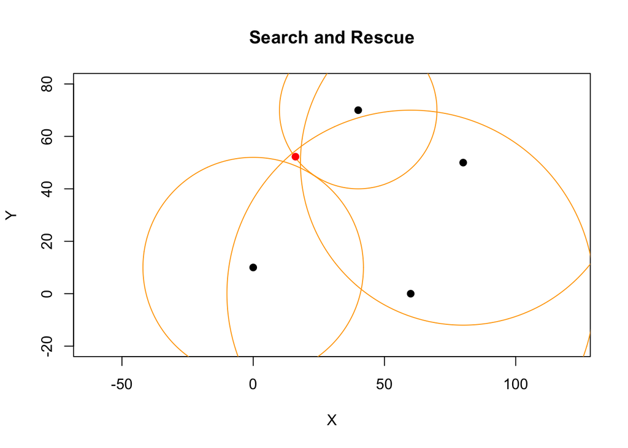

```r
tx <- c(0,60,80,40)
ty <- c(10,0,50,70)
d <- c(42,70,62,30)
tt <- seq(0,2*pi,length=800)
plot(tx,ty,'p',pch=19,asp=1,
     xlim=c(-20,80),ylim=c(-20,80),
     main="Search and Rescue",
     xlab="X",ylab="Y")
for (j in 1:4){
  lines(tx[j]+cos(tt)*d[j],ty[j]+sin(tt)*d[j],col="orange")
}
points(v[1], v[2], 'p', pch=19, col='red')
```

I use the first method to get the error function and minimize the value of that through Newton’s method. I get the Hessian matrix of second derivatives and gradient (vector of first derivatives) to solve the problem. And I figure out the suggested destination in the graph with the red point.